# Coursera Practical Machine Learning Project

Anna H

2025-03-01

### Introduction

This report details the development of a machine learning model for activity recognition using data from accelerometers on the belt, forearm, arm, and dumbbell of 6 participants. The goal was to predict the manner in which they performed barbell lifts, classified into five categories (in the *classe* variable):

- A - exactly according to the specification
- B - throwing the elbows to the front
- C - lifting the dumbbell only halfway
- D - lowering the dumbbell only halfway
- E - throwing the hips to the front

### Data Preparation and Exploratory Analysis

Our first step is to read in the data and clean it to make sure we only use the fields that are helpful in our predictions. The documentation for the original project that describes the data mentions 40 such fields out of the total 154. So, we will be using those 40 features as a starting point for our classification.

We will graph the distribution of the classes to get an better idea of the *classe* variable distribution in our data, and we will also check to make sure that are no rows left with missing information. And we see that there are 0 such rows.

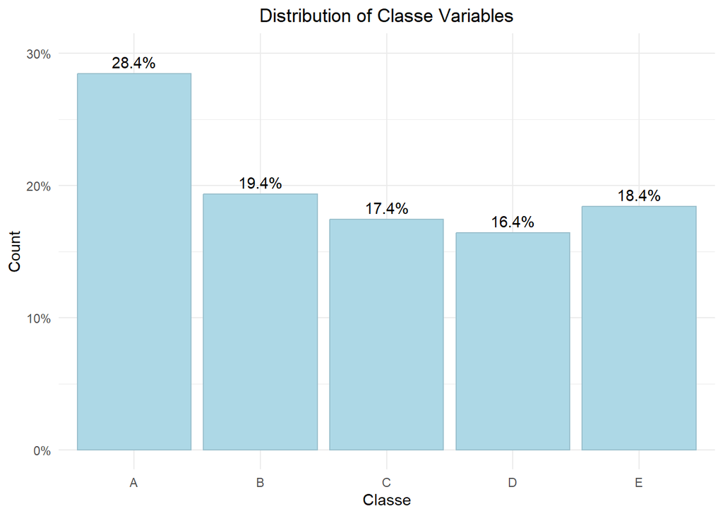

Next, the *classe* variable is separated from the dataset for ease of model training. We then set a seed for reproducibility and split all of the data (the main dataset with the measurements and the one containing the classe information) into matching training and testing sets. The training dataset will be 70% of the original (13,737 total observations) and the rest (5,885 total observations) will be left for model testing.

We will now take a look at the variability within our data set by looking at the coefficients of variation (CV) for each feature to see how large or small it is. First we see that there are several variables that have extreme (>1,000 or 10 times the mean) coefficients of variation. Suggesting extreme amounts of variation within the dataset.

```
## [1] "pitch_belt, gyros_belt_x, yaw_arm, yaw_dumbbell, gyros_dumbbell_x, gyros_dumbbell_y, gyros_dumbbell_z, gyros_forearm_y, gyros_forearm_z"
```

The median absolute deviation (MAD) values, which are less sensitive to outliers than CVs also shows quite a bit of variability as seen on the chart below (one extreme outlier has been left off - magnet_arm_x with a value of 618.24).

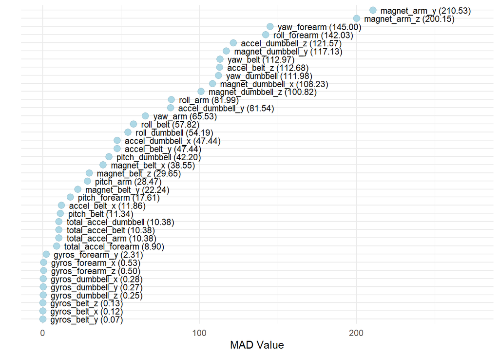

### Model Building

#### Algorithm Selection

Since this a classification problem, we will be using a decision tree approach to get our *classe* prediction. However, a basic decision tree creates only one tree and may not capture the necessary relationships leading to a low level of accuracy. Therefore we will be utilizing an instance of bagging, which will allow us to train multiple models to get a better result. In this case, we chose a random forest method for the final model creation due its strong predictive performance and ability to capture non-linear relationships between variables without explicit specification of their relationships. Random forests are also known to help prevent overfitting, which is likely to happen when there’s high variance, like in this data. This method also provides measures of variable importance that can potentially reduce the number of variables needed.

#### Cross-Validation and Hyperparameter Tuning

An important step in training a good model is to select the appropriate parameters. A grid search with 10-fold k-fold cross-validation was done to tune the hyperparameters for the

- number of trees to grow (*ntree* is evaluated at values of 100, 500 and 1000
- number of features to randomly sample at each tree split (*mtry* is evaluated at 6, 13 and 20)
- sample tree sizes (bootstrap size is evaluated at 500, 1000 and 1500)

For each combination, stratified sampling for bootstrapping was used and the model’s accuracy was evaluated using cross-validation. Unfortunately, this negatively affected the processing time. The best parameters were selected as follows:

- number of features - 6
- number of trees - 100
- sample tree size - 1500

### Model Training and Evaluation

Next, those parameters were used to train a random forest model on a randomly selected part of the training set.

```r
        trainIndices <- createDataPartition(trainingClasse,
                                      p = bootstrapSize / length(trainingClasse),
                                      list = FALSE)
        bootstrapTraining <- training[trainIndices, ]
        bootstrapClasse <- trainingClasse[trainIndices]

        basicModel <- train(x = bootstrapTraining,
               y = bootstrapClasse,
               method = "rf",
               trControl = trainControl(method = "cv", number = 10),
               metric = "Accuracy",
               tuneGrid = expand.grid(.mtry = mtry),
               ntree = ntree)
```

After making predictions the model is evaluated by looking at the confusion matrix.

Overall, the model appear to have 93.63% accuracy, which means that correctly classifies the vast majority of data. The Cohen’s kappa for our model is 0.919, a value very close to 1. This means that the agreement between predicted and actual classes is not likely to have happened by chance.

The average of the F1 scores across the classes is 93.24%, which also suggests a high prediction quality that is also confirmed by the weighted-averaged of the F1 scores (93.64%).

```
## Confusion Matrix and Statistics
##
##           Reference
## Prediction    A    B    C    D    E
##          A 3835  134   17   32    5
##          B   19 2375  119   21   23
##          C   22  116 2207  169   36
##          D   18   20   24 1996   12
##          E   12   13   29   34 2449
##
## Overall Statistics
##
##                Accuracy : 0.9363
##                  95% CI : (0.9321, 0.9403)
##     No Information Rate : 0.2843
##     P-Value [Acc > NIR] : < 0.00000000000000022
##
##                   Kappa : 0.9193
##
##  Mcnemar's Test P-Value : < 0.00000000000000022
##
## Statistics by Class:
##
##                      Class: A Class: B Class: C Class: D Class: E
## Sensitivity            0.9818   0.8935   0.9211   0.8863   0.9699
## Specificity            0.9809   0.9836   0.9698   0.9936   0.9922
## Pos Pred Value         0.9533   0.9288   0.8655   0.9643   0.9653
## Neg Pred Value         0.9927   0.9747   0.9831   0.9781   0.9932
## Precision              0.9533   0.9288   0.8655   0.9643   0.9653
## Recall                 0.9818   0.8935   0.9211   0.8863   0.9699
## F1                     0.9673   0.9108   0.8924   0.9236   0.9676
## Prevalence             0.2843   0.1935   0.1744   0.1639   0.1838
## Detection Rate         0.2792   0.1729   0.1607   0.1453   0.1783
## Detection Prevalence   0.2929   0.1861   0.1856   0.1507   0.1847
## Balanced Accuracy      0.9813   0.9386   0.9454   0.9399   0.9810
```

To confirm that the model is not overfitting, we will test its predictions on the testing data set that we separated from the training set earlier. With this never seen data we can confirm that the model is still performing well across all classes, with high accuracy (91.73%), the difference of about 1.90% with the accuracy for the training set suggests there might be slight overfitting. The model also has a strong kappa (0.895) and the average F1 of 91.12%, which still shows a strong agreement between predicted and actual classes and a good prediction quality.

When we create an ROC curve for both the training and testing set models we can also see that the area under the curve for each of the classes in both models is very close the the perfect measure of 1, confirming that the model is quite good at distinguishing between classes across various thresholds.

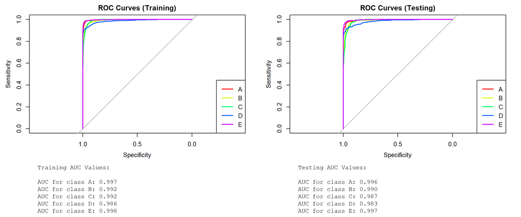

### Expected Out-of-Sample Error

Given the test set accuracy of 91.73%, the expected out-of-sample error is approximately 1-accuracy = 8.27%. This estimate is based on the test set performance, which is a bit lower than the training set accuracy. However, it’s important to note that this error rate might still be a little optimistic, and the performance on entirely new data could be slightly lower.